# Risk Factor Analysis

## Outcome Variable

**Outcome Variable:** stunted

## Predictor Variables

**Intervention Variable:** meducyrs

**Adjustment Set:**

- arm
- W_mage
- feducyrs
- W_mhtcm
- W_gagebrth
- W_birthwt
- W_birthlen
- single
- impsan
- delta_W_mage
- delta_feducyrs
- delta_W_mhtcm
- delta_W_gagebrth
- delta_W_birthwt
- delta_W_birthlen
- delta_single
- delta_impsan

## Stratifying Variables

The analysis was stratified on these variable(s):

- agecat
- studyid
- country

## Data Summary

| agecat | studyid | country | meducyrs | stunted | n_cell | n |
| --- | --- | --- | --- | --- | --- | --- |
| Birth | ki0047075b-MAL-ED | BANGLADESH | High | 0 | 66 | 207 |
| Birth | ki0047075b-MAL-ED | BANGLADESH | High | 1 | 9 | 207 |
| Birth | ki0047075b-MAL-ED | BANGLADESH | Low | 0 | 51 | 207 |
| Birth | ki0047075b-MAL-ED | BANGLADESH | Low | 1 | 17 | 207 |
| Birth | ki0047075b-MAL-ED | BANGLADESH | Medium | 0 | 54 | 207 |
| Birth | ki0047075b-MAL-ED | BANGLADESH | Medium | 1 | 10 | 207 |
| Birth | ki0047075b-MAL-ED | BRAZIL | High | 0 | 58 | 190 |
| Birth | ki0047075b-MAL-ED | BRAZIL | High | 1 | 7 | 190 |
| Birth | ki0047075b-MAL-ED | BRAZIL | Low | 0 | 46 | 190 |
| Birth | ki0047075b-MAL-ED | BRAZIL | Low | 1 | 6 | 190 |
| Birth | ki0047075b-MAL-ED | BRAZIL | Medium | 0 | 65 | 190 |
| Birth | ki0047075b-MAL-ED | BRAZIL | Medium | 1 | 8 | 190 |
| Birth | ki0047075b-MAL-ED | INDIA | High | 0 | 42 | 183 |
| Birth | ki0047075b-MAL-ED | INDIA | High | 1 | 9 | 183 |
| Birth | ki0047075b-MAL-ED | INDIA | Low | 0 | 55 | 183 |
| Birth | ki0047075b-MAL-ED | INDIA | Low | 1 | 6 | 183 |
| Birth | ki0047075b-MAL-ED | INDIA | Medium | 0 | 59 | 183 |
| Birth | ki0047075b-MAL-ED | INDIA | Medium | 1 | 12 | 183 |
| Birth | ki0047075b-MAL-ED | NEPAL | High | 0 | 34 | 160 |
| Birth | ki0047075b-MAL-ED | NEPAL | High | 1 | 3 | 160 |
| Birth | ki0047075b-MAL-ED | NEPAL | Low | 0 | 60 | 160 |
| Birth | ki0047075b-MAL-ED | NEPAL | Low | 1 | 8 | 160 |
| Birth | ki0047075b-MAL-ED | NEPAL | Medium | 0 | 49 | 160 |
| Birth | ki0047075b-MAL-ED | NEPAL | Medium | 1 | 6 | 160 |
| Birth | ki0047075b-MAL-ED | PERU | High | 0 | 77 | 286 |
| Birth | ki0047075b-MAL-ED | PERU | High | 1 | 10 | 286 |
| Birth | ki0047075b-MAL-ED | PERU | Low | 0 | 85 | 286 |
| Birth | ki0047075b-MAL-ED | PERU | Low | 1 | 14 | 286 |
| Birth | ki0047075b-MAL-ED | PERU | Medium | 0 | 90 | 286 |
| Birth | ki0047075b-MAL-ED | PERU | Medium | 1 | 10 | 286 |

[output cut: 378 more lines]

The following strata were considered:

- agecat: 24 months, studyid: ki0047075b-MAL-ED, country: BANGLADESH
- agecat: 24 months, studyid: ki0047075b-MAL-ED, country: BRAZIL
- agecat: 24 months, studyid: ki0047075b-MAL-ED, country: INDIA
- agecat: 24 months, studyid: ki0047075b-MAL-ED, country: NEPAL
- agecat: 24 months, studyid: ki0047075b-MAL-ED, country: PERU
- agecat: 24 months, studyid: ki0047075b-MAL-ED, country: SOUTH AFRICA
- agecat: 24 months, studyid: ki0047075b-MAL-ED, country: TANZANIA, UNITED REPUBLIC OF
- agecat: 24 months, studyid: ki1000108-CMC-V-BCS-2002, country: INDIA
- agecat: 24 months, studyid: ki1000108-IRC, country: INDIA
- agecat: 24 months, studyid: ki1017093-NIH-Birth, country: BANGLADESH
- agecat: 24 months, studyid: ki1017093b-PROVIDE, country: BANGLADESH
- agecat: 24 months, studyid: ki1017093c-NIH-Crypto, country: BANGLADESH
- agecat: 24 months, studyid: ki1066203-TanzaniaChild2, country: TANZANIA, UNITED REPUBLIC OF
- agecat: 24 months, studyid: ki1113344-GMS-Nepal, country: NEPAL
- agecat: 24 months, studyid: ki1119695-PROBIT, country: BELARUS
- agecat: 24 months, studyid: ki1126311-ZVITAMBO, country: ZIMBABWE
- agecat: 24 months, studyid: ki1135781-COHORTS, country: GUATEMALA
- agecat: 24 months, studyid: ki1135781-COHORTS, country: INDIA
- agecat: 24 months, studyid: ki1135781-COHORTS, country: PHILIPPINES
- agecat: 24 months, studyid: ki1148112-LCNI-5, country: MALAWI
- agecat: 24 months, studyid: kiGH5241-JiVitA-3, country: BANGLADESH
- agecat: 24 months, studyid: kiGH5241-JiVitA-4, country: BANGLADESH
- agecat: 6 months, studyid: ki0047075b-MAL-ED, country: BANGLADESH
- agecat: 6 months, studyid: ki0047075b-MAL-ED, country: BRAZIL
- agecat: 6 months, studyid: ki0047075b-MAL-ED, country: INDIA
- agecat: 6 months, studyid: ki0047075b-MAL-ED, country: NEPAL
- agecat: 6 months, studyid: ki0047075b-MAL-ED, country: PERU
- agecat: 6 months, studyid: ki0047075b-MAL-ED, country: SOUTH AFRICA
- agecat: 6 months, studyid: ki0047075b-MAL-ED, country: TANZANIA, UNITED REPUBLIC OF
- agecat: 6 months, studyid: ki1000108-CMC-V-BCS-2002, country: INDIA
- agecat: 6 months, studyid: ki1000108-IRC, country: INDIA
- agecat: 6 months, studyid: ki1000109-EE, country: PAKISTAN
- agecat: 6 months, studyid: ki1000304b-SAS-CompFeed, country: INDIA
- agecat: 6 months, studyid: ki1000304b-SAS-FoodSuppl, country: INDIA
- agecat: 6 months, studyid: ki1017093-NIH-Birth, country: BANGLADESH
- agecat: 6 months, studyid: ki1017093b-PROVIDE, country: BANGLADESH
- agecat: 6 months, studyid: ki1017093c-NIH-Crypto, country: BANGLADESH
- agecat: 6 months, studyid: ki1066203-TanzaniaChild2, country: TANZANIA, UNITED REPUBLIC OF
- agecat: 6 months, studyid: ki1112895-Guatemala BSC, country: GUATEMALA
- agecat: 6 months, studyid: ki1113344-GMS-Nepal, country: NEPAL
- agecat: 6 months, studyid: ki1119695-PROBIT, country: BELARUS
- agecat: 6 months, studyid: ki1126311-ZVITAMBO, country: ZIMBABWE
- agecat: 6 months, studyid: ki1135781-COHORTS, country: GUATEMALA
- agecat: 6 months, studyid: ki1135781-COHORTS, country: INDIA
- agecat: 6 months, studyid: ki1135781-COHORTS, country: PHILIPPINES
- agecat: 6 months, studyid: ki1148112-LCNI-5, country: MALAWI
- agecat: 6 months, studyid: kiGH5241-JiVitA-3, country: BANGLADESH
- agecat: 6 months, studyid: kiGH5241-JiVitA-4, country: BANGLADESH
- agecat: Birth, studyid: ki0047075b-MAL-ED, country: BANGLADESH
- agecat: Birth, studyid: ki0047075b-MAL-ED, country: BRAZIL
- agecat: Birth, studyid: ki0047075b-MAL-ED, country: INDIA
- agecat: Birth, studyid: ki0047075b-MAL-ED, country: NEPAL
- agecat: Birth, studyid: ki0047075b-MAL-ED, country: PERU
- agecat: Birth, studyid: ki0047075b-MAL-ED, country: SOUTH AFRICA
- agecat: Birth, studyid: ki0047075b-MAL-ED, country: TANZANIA, UNITED REPUBLIC OF
- agecat: Birth, studyid: ki1000108-CMC-V-BCS-2002, country: INDIA
- agecat: Birth, studyid: ki1000108-IRC, country: INDIA
- agecat: Birth, studyid: ki1000109-EE, country: PAKISTAN
- agecat: Birth, studyid: ki1000304b-SAS-CompFeed, country: INDIA
- agecat: Birth, studyid: ki1017093-NIH-Birth, country: BANGLADESH
- agecat: Birth, studyid: ki1017093c-NIH-Crypto, country: BANGLADESH
- agecat: Birth, studyid: ki1119695-PROBIT, country: BELARUS
- agecat: Birth, studyid: ki1126311-ZVITAMBO, country: ZIMBABWE
- agecat: Birth, studyid: ki1135781-COHORTS, country: GUATEMALA
- agecat: Birth, studyid: ki1135781-COHORTS, country: INDIA
- agecat: Birth, studyid: ki1135781-COHORTS, country: PHILIPPINES
- agecat: Birth, studyid: kiGH5241-JiVitA-3, country: BANGLADESH
- agecat: Birth, studyid: kiGH5241-JiVitA-4, country: BANGLADESH

### Dropped Strata

Some strata were dropped due to rare outcomes:

- agecat: Birth, studyid: ki0047075b-MAL-ED, country: NEPAL
- agecat: Birth, studyid: ki0047075b-MAL-ED, country: TANZANIA, UNITED REPUBLIC OF
- agecat: Birth, studyid: ki1000108-CMC-V-BCS-2002, country: INDIA
- agecat: Birth, studyid: ki1000109-EE, country: PAKISTAN
- agecat: Birth, studyid: ki1017093-NIH-Birth, country: BANGLADESH
- agecat: Birth, studyid: ki1017093c-NIH-Crypto, country: BANGLADESH
- agecat: Birth, studyid: ki1119695-PROBIT, country: BELARUS
- agecat: Birth, studyid: kiGH5241-JiVitA-4, country: BANGLADESH
- agecat: 6 months, studyid: ki0047075b-MAL-ED, country: BRAZIL
- agecat: 6 months, studyid: ki0047075b-MAL-ED, country: NEPAL
- agecat: 6 months, studyid: ki0047075b-MAL-ED, country: TANZANIA, UNITED REPUBLIC OF
- agecat: 24 months, studyid: ki0047075b-MAL-ED, country: BRAZIL
- agecat: 24 months, studyid: ki0047075b-MAL-ED, country: TANZANIA, UNITED REPUBLIC OF
- agecat: 24 months, studyid: ki1066203-TanzaniaChild2, country: TANZANIA, UNITED REPUBLIC OF

## Methods Detail

We’re interested in the causal parameters $E[Y_a]$ for all values of $a \in \mathcal{A}$. These parameters represent the mean outcome if, possibly contrary to fact, we intervened to set all units to have $A=a$. Under the randomization and positivity assumptions, these are identified by the statistical parameters $\psi_a=E_W[E_{Y|A,W}(Y|A=a,W)]$. In addition, we’re interested in the mean of $Y$, $E[Y]$ under no intervention (the observed mean). We will estimate these parameters by using SuperLearner to fit the relevant likelihood factors – $E_{Y|A,W}(Y|A=a,W)$ and $p(A=a|W)$, and then updating our likelihood fit using a joint TMLE.

For unadjusted analyses ($W=\{\}$), initial likelihoods were estimated using Lrnr_glm to estimate the simple $E(Y|A)$ and Lrnr_mean to estimate $p(A)$. For adjusted analyses, a small library containing Lrnr_glmnet, Lrnr_xgboost, and Lrnr_mean was used.

Having estimated these parameters, we will then use the delta method to estimate relative risks and attributable risks relative to a prespecified baseline level of $A$.

# Results Detail

## Results Plots

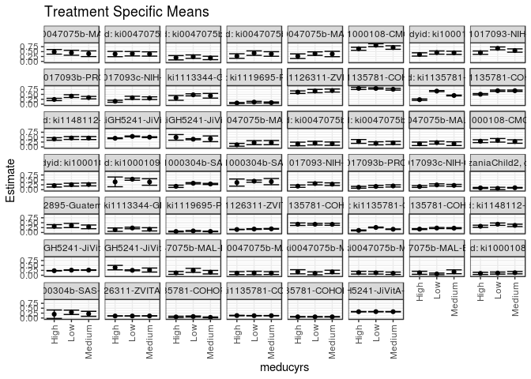

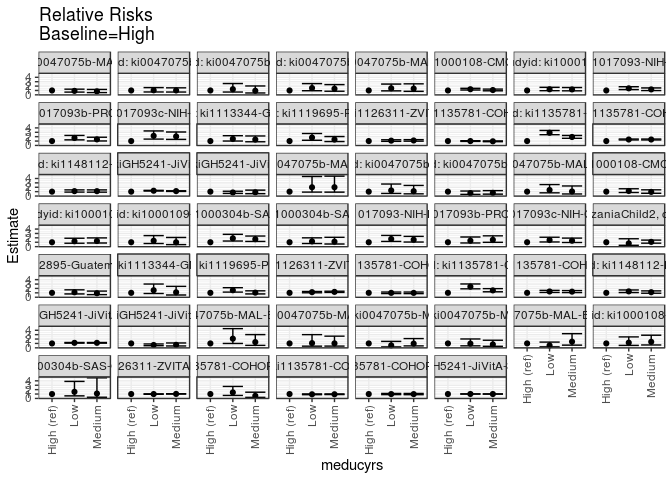

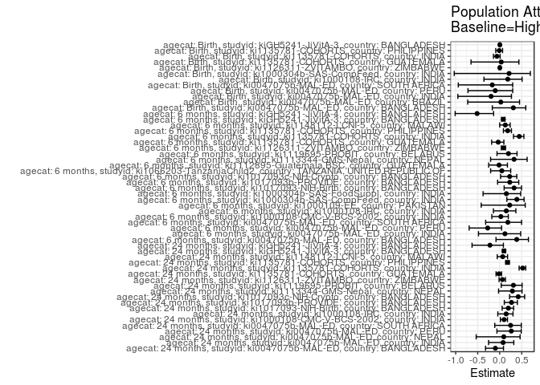

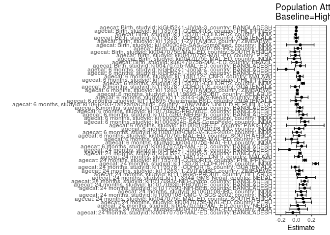

## Results Table

### Parameter: TSM

| agecat | studyid | country | intervention_level | baseline_level | estimate | ci_lower | ci_upper |
| --- | --- | --- | --- | --- | --- | --- | --- |
| Birth | ki0047075b-MAL-ED | BANGLADESH | High | NA | 0.1200000 | 0.0462773 | 0.1937227 |
| Birth | ki0047075b-MAL-ED | BANGLADESH | Low | NA | 0.2500000 | 0.1468318 | 0.3531682 |
| Birth | ki0047075b-MAL-ED | BANGLADESH | Medium | NA | 0.1562500 | 0.0670784 | 0.2454216 |
| Birth | ki0047075b-MAL-ED | BRAZIL | High | NA | 0.1076923 | 0.0321332 | 0.1832514 |
| Birth | ki0047075b-MAL-ED | BRAZIL | Low | NA | 0.1153846 | 0.0283196 | 0.2024496 |
| Birth | ki0047075b-MAL-ED | BRAZIL | Medium | NA | 0.1095890 | 0.0377416 | 0.1814365 |
| Birth | ki0047075b-MAL-ED | INDIA | High | NA | 0.1764706 | 0.0715578 | 0.2813834 |
| Birth | ki0047075b-MAL-ED | INDIA | Low | NA | 0.0983607 | 0.0234230 | 0.1732983 |
| Birth | ki0047075b-MAL-ED | INDIA | Medium | NA | 0.1690141 | 0.0816029 | 0.2564253 |
| Birth | ki0047075b-MAL-ED | PERU | High | NA | 0.1309083 | 0.0611186 | 0.2006980 |
| Birth | ki0047075b-MAL-ED | PERU | Low | NA | 0.1256820 | 0.0598989 | 0.1914650 |
| Birth | ki0047075b-MAL-ED | PERU | Medium | NA | 0.1011964 | 0.0397345 | 0.1626584 |
| Birth | ki0047075b-MAL-ED | SOUTH AFRICA | High | NA | 0.1250000 | 0.0484630 | 0.2015370 |
| Birth | ki0047075b-MAL-ED | SOUTH AFRICA | Low | NA | 0.0676692 | 0.0248998 | 0.1104386 |
| Birth | ki0047075b-MAL-ED | SOUTH AFRICA | Medium | NA | 0.1754386 | 0.0765115 | 0.2743657 |
| Birth | ki1000108-IRC | INDIA | High | NA | 0.0947480 | 0.0392316 | 0.1502645 |
| Birth | ki1000108-IRC | INDIA | Low | NA | 0.1110820 | 0.0588262 | 0.1633379 |
| Birth | ki1000108-IRC | INDIA | Medium | NA | 0.1297585 | 0.0710140 | 0.1885030 |
| Birth | ki1000304b-SAS-CompFeed | INDIA | High | NA | 0.1935484 | -0.0222467 | 0.4093435 |
| Birth | ki1000304b-SAS-CompFeed | INDIA | Low | NA | 0.2906977 | 0.1800337 | 0.4013617 |
| Birth | ki1000304b-SAS-CompFeed | INDIA | Medium | NA | 0.2142857 | 0.0869223 | 0.3416491 |
| Birth | ki1126311-ZVITAMBO | ZIMBABWE | High | NA | 0.1033952 | 0.0979713 | 0.1088192 |
| Birth | ki1126311-ZVITAMBO | ZIMBABWE | Low | NA | 0.1028159 | 0.0963224 | 0.1093095 |
| Birth | ki1126311-ZVITAMBO | ZIMBABWE | Medium | NA | 0.1060325 | 0.0998385 | 0.1122265 |
| Birth | ki1135781-COHORTS | GUATEMALA | High | NA | 0.0561798 | 0.0223319 | 0.0900276 |
| Birth | ki1135781-COHORTS | GUATEMALA | Low | NA | 0.0767263 | 0.0503293 | 0.1031234 |
| Birth | ki1135781-COHORTS | GUATEMALA | Medium | NA | 0.0329670 | 0.0117744 | 0.0541597 |
| Birth | ki1135781-COHORTS | INDIA | High | NA | 0.1258157 | 0.1132880 | 0.1383434 |
| Birth | ki1135781-COHORTS | INDIA | Low | NA | 0.1180875 | 0.1077617 | 0.1284133 |
| Birth | ki1135781-COHORTS | INDIA | Medium | NA | 0.1192275 | 0.1098205 | 0.1286345 |

[output cut: 132 more lines]

### Parameter: E(Y)

| agecat | studyid | country | intervention_level | baseline_level | estimate | ci_lower | ci_upper |
| --- | --- | --- | --- | --- | --- | --- | --- |
| Birth | ki0047075b-MAL-ED | BANGLADESH | NA | NA | 0.1739130 | 0.1221531 | 0.2256729 |
| Birth | ki0047075b-MAL-ED | BRAZIL | NA | NA | 0.1105263 | 0.0658254 | 0.1552272 |
| Birth | ki0047075b-MAL-ED | INDIA | NA | NA | 0.1475410 | 0.0960175 | 0.1990645 |
| Birth | ki0047075b-MAL-ED | PERU | NA | NA | 0.1188811 | 0.0813061 | 0.1564562 |
| Birth | ki0047075b-MAL-ED | SOUTH AFRICA | NA | NA | 0.1068702 | 0.0693890 | 0.1443514 |
| Birth | ki1000108-IRC | INDIA | NA | NA | 0.1159794 | 0.0840777 | 0.1478811 |
| Birth | ki1000304b-SAS-CompFeed | INDIA | NA | NA | 0.2459893 | 0.1594019 | 0.3325767 |
| Birth | ki1126311-ZVITAMBO | ZIMBABWE | NA | NA | 0.1036930 | 0.0986082 | 0.1087777 |
| Birth | ki1135781-COHORTS | GUATEMALA | NA | NA | 0.0581948 | 0.0423724 | 0.0740172 |
| Birth | ki1135781-COHORTS | INDIA | NA | NA | 0.1182899 | 0.1095248 | 0.1270550 |
| Birth | ki1135781-COHORTS | PHILIPPINES | NA | NA | 0.0613115 | 0.0527962 | 0.0698268 |
| Birth | kiGH5241-JiVitA-3 | BANGLADESH | NA | NA | 0.3232756 | 0.3156176 | 0.3309337 |
| 6 months | ki0047075b-MAL-ED | BANGLADESH | NA | NA | 0.1785714 | 0.1248161 | 0.2323268 |
| 6 months | ki0047075b-MAL-ED | INDIA | NA | NA | 0.1730769 | 0.1215404 | 0.2246134 |
| 6 months | ki0047075b-MAL-ED | PERU | NA | NA | 0.2205882 | 0.1712211 | 0.2699554 |
| 6 months | ki0047075b-MAL-ED | SOUTH AFRICA | NA | NA | 0.1968504 | 0.1478551 | 0.2458457 |
| 6 months | ki1000108-CMC-V-BCS-2002 | INDIA | NA | NA | 0.3008130 | 0.2539566 | 0.3476694 |
| 6 months | ki1000108-IRC | INDIA | NA | NA | 0.2457002 | 0.2038248 | 0.2875757 |
| 6 months | ki1000109-EE | PAKISTAN | NA | NA | 0.5176152 | 0.4665618 | 0.5686686 |
| 6 months | ki1000304b-SAS-CompFeed | INDIA | NA | NA | 0.2844311 | 0.2666491 | 0.3022132 |
| 6 months | ki1000304b-SAS-FoodSuppl | INDIA | NA | NA | 0.4289474 | 0.3791199 | 0.4787748 |
| 6 months | ki1017093-NIH-Birth | BANGLADESH | NA | NA | 0.2681564 | 0.2306532 | 0.3056597 |
| 6 months | ki1017093b-PROVIDE | BANGLADESH | NA | NA | 0.1612350 | 0.1313580 | 0.1911120 |
| 6 months | ki1017093c-NIH-Crypto | BANGLADESH | NA | NA | 0.2097902 | 0.1799252 | 0.2396552 |
| 6 months | ki1066203-TanzaniaChild2 | TANZANIA, UNITED REPUBLIC OF | NA | NA | 0.0964869 | 0.0836111 | 0.1093627 |
| 6 months | ki1112895-Guatemala BSC | GUATEMALA | NA | NA | 0.3104693 | 0.2558835 | 0.3650551 |
| 6 months | ki1113344-GMS-Nepal | NEPAL | NA | NA | 0.2125000 | 0.1785885 | 0.2464115 |
| 6 months | ki1119695-PROBIT | BELARUS | NA | NA | 0.0626864 | 0.0488489 | 0.0765238 |
| 6 months | ki1126311-ZVITAMBO | ZIMBABWE | NA | NA | 0.1665057 | 0.1584820 | 0.1745293 |
| 6 months | ki1135781-COHORTS | GUATEMALA | NA | NA | 0.4075630 | 0.3763327 | 0.4387933 |
| 6 months | ki1135781-COHORTS | INDIA | NA | NA | 0.1915758 | 0.1810911 | 0.2020606 |
| 6 months | ki1135781-COHORTS | PHILIPPINES | NA | NA | 0.2112260 | 0.1958496 | 0.2266024 |
| 6 months | ki1148112-LCNI-5 | MALAWI | NA | NA | 0.3628536 | 0.3297820 | 0.3959252 |
| 6 months | kiGH5241-JiVitA-3 | BANGLADESH | NA | NA | 0.2514589 | 0.2433251 | 0.2595926 |
| 6 months | kiGH5241-JiVitA-4 | BANGLADESH | NA | NA | 0.2573674 | 0.2348896 | 0.2798452 |
| 24 months | ki0047075b-MAL-ED | BANGLADESH | NA | NA | 0.4444444 | 0.3697487 | 0.5191402 |
| 24 months | ki0047075b-MAL-ED | INDIA | NA | NA | 0.4070352 | 0.3386053 | 0.4754651 |
| 24 months | ki0047075b-MAL-ED | NEPAL | NA | NA | 0.2065728 | 0.1520761 | 0.2610695 |
| 24 months | ki0047075b-MAL-ED | PERU | NA | NA | 0.3700000 | 0.3029201 | 0.4370799 |
| 24 months | ki0047075b-MAL-ED | SOUTH AFRICA | NA | NA | 0.3529412 | 0.2921001 | 0.4137823 |
| 24 months | ki1000108-CMC-V-BCS-2002 | INDIA | NA | NA | 0.7150538 | 0.6691221 | 0.7609854 |
| 24 months | ki1000108-IRC | INDIA | NA | NA | 0.4156479 | 0.3678270 | 0.4634689 |
| 24 months | ki1017093-NIH-Birth | BANGLADESH | NA | NA | 0.5547786 | 0.5076945 | 0.6018626 |
| 24 months | ki1017093b-PROVIDE | BANGLADESH | NA | NA | 0.3292894 | 0.2909105 | 0.3676684 |
| 24 months | ki1017093c-NIH-Crypto | BANGLADESH | NA | NA | 0.2568093 | 0.2190047 | 0.2946140 |
| 24 months | ki1113344-GMS-Nepal | NEPAL | NA | NA | 0.4495968 | 0.4057742 | 0.4934193 |
| 24 months | ki1119695-PROBIT | BELARUS | NA | NA | 0.0852540 | 0.0554439 | 0.1150642 |
| 24 months | ki1126311-ZVITAMBO | ZIMBABWE | NA | NA | 0.6520788 | 0.6083612 | 0.6957964 |
| 24 months | ki1135781-COHORTS | GUATEMALA | NA | NA | 0.7905660 | 0.7660589 | 0.8150732 |
| 24 months | ki1135781-COHORTS | INDIA | NA | NA | 0.4815520 | 0.4664409 | 0.4966632 |
| 24 months | ki1135781-COHORTS | PHILIPPINES | NA | NA | 0.6167689 | 0.5974942 | 0.6360437 |
| 24 months | ki1148112-LCNI-5 | MALAWI | NA | NA | 0.4370629 | 0.3963782 | 0.4777477 |
| 24 months | kiGH5241-JiVitA-3 | BANGLADESH | NA | NA | 0.4907783 | 0.4776560 | 0.5039007 |
| 24 months | kiGH5241-JiVitA-4 | BANGLADESH | NA | NA | 0.3988036 | 0.3729992 | 0.4246080 |

### Parameter: RR

| agecat | studyid | country | intervention_level | baseline_level | estimate | ci_lower | ci_upper |
| --- | --- | --- | --- | --- | --- | --- | --- |
| Birth | ki0047075b-MAL-ED | BANGLADESH | High | High | 1.0000000 | 1.0000000 | 1.0000000 |
| Birth | ki0047075b-MAL-ED | BANGLADESH | Low | High | 2.0833333 | 0.9938990 | 4.3669202 |
| Birth | ki0047075b-MAL-ED | BANGLADESH | Medium | High | 1.3020833 | 0.5629511 | 3.0116663 |
| Birth | ki0047075b-MAL-ED | BRAZIL | High | High | 1.0000000 | 1.0000000 | 1.0000000 |
| Birth | ki0047075b-MAL-ED | BRAZIL | Low | High | 1.0714286 | 0.3823707 | 3.0022156 |
| Birth | ki0047075b-MAL-ED | BRAZIL | Medium | High | 1.0176125 | 0.3895365 | 2.6583777 |
| Birth | ki0047075b-MAL-ED | INDIA | High | High | 1.0000000 | 1.0000000 | 1.0000000 |
| Birth | ki0047075b-MAL-ED | INDIA | Low | High | 0.5573771 | 0.2120599 | 1.4650071 |
| Birth | ki0047075b-MAL-ED | INDIA | Medium | High | 0.9577465 | 0.4355463 | 2.1060408 |
| Birth | ki0047075b-MAL-ED | PERU | High | High | 1.0000000 | 1.0000000 | 1.0000000 |
| Birth | ki0047075b-MAL-ED | PERU | Low | High | 0.9600763 | 0.4571536 | 2.0162727 |
| Birth | ki0047075b-MAL-ED | PERU | Medium | High | 0.7730330 | 0.3448805 | 1.7327163 |
| Birth | ki0047075b-MAL-ED | SOUTH AFRICA | High | High | 1.0000000 | 1.0000000 | 1.0000000 |
| Birth | ki0047075b-MAL-ED | SOUTH AFRICA | Low | High | 0.5413534 | 0.2245471 | 1.3051312 |
| Birth | ki0047075b-MAL-ED | SOUTH AFRICA | Medium | High | 1.4035088 | 0.6105386 | 3.2263919 |
| Birth | ki1000108-IRC | INDIA | High | High | 1.0000000 | 1.0000000 | 1.0000000 |
| Birth | ki1000108-IRC | INDIA | Low | High | 1.1723943 | 0.5532102 | 2.4846041 |
| Birth | ki1000108-IRC | INDIA | Medium | High | 1.3695116 | 0.6518233 | 2.8774089 |
| Birth | ki1000304b-SAS-CompFeed | INDIA | High | High | 1.0000000 | 1.0000000 | 1.0000000 |
| Birth | ki1000304b-SAS-CompFeed | INDIA | Low | High | 1.5019380 | 0.5821735 | 3.8748203 |
| Birth | ki1000304b-SAS-CompFeed | INDIA | Medium | High | 1.1071429 | 0.2616557 | 4.6846500 |
| Birth | ki1126311-ZVITAMBO | ZIMBABWE | High | High | 1.0000000 | 1.0000000 | 1.0000000 |
| Birth | ki1126311-ZVITAMBO | ZIMBABWE | Low | High | 0.9943971 | 0.9450577 | 1.0463125 |
| Birth | ki1126311-ZVITAMBO | ZIMBABWE | Medium | High | 1.0255069 | 0.9797753 | 1.0733730 |
| Birth | ki1135781-COHORTS | GUATEMALA | High | High | 1.0000000 | 1.0000000 | 1.0000000 |
| Birth | ki1135781-COHORTS | GUATEMALA | Low | High | 1.3657289 | 0.6824179 | 2.7332451 |
| Birth | ki1135781-COHORTS | GUATEMALA | Medium | High | 0.5868132 | 0.2431453 | 1.4162299 |
| Birth | ki1135781-COHORTS | INDIA | High | High | 1.0000000 | 1.0000000 | 1.0000000 |
| Birth | ki1135781-COHORTS | INDIA | Low | High | 0.9385753 | 0.8553951 | 1.0298441 |
| Birth | ki1135781-COHORTS | INDIA | Medium | High | 0.9476364 | 0.8721266 | 1.0296838 |

[output cut: 132 more lines]

### Parameter: PAR

| agecat | studyid | country | intervention_level | baseline_level | estimate | ci_lower | ci_upper |
| --- | --- | --- | --- | --- | --- | --- | --- |
| Birth | ki0047075b-MAL-ED | BANGLADESH | High | NA | 0.0539130 | -0.0107065 | 0.1185326 |
| Birth | ki0047075b-MAL-ED | BRAZIL | High | NA | 0.0028340 | -0.0588188 | 0.0644869 |
| Birth | ki0047075b-MAL-ED | INDIA | High | NA | -0.0289296 | -0.1156850 | 0.0578257 |
| Birth | ki0047075b-MAL-ED | PERU | High | NA | -0.0120272 | -0.0704087 | 0.0463544 |
| Birth | ki0047075b-MAL-ED | SOUTH AFRICA | High | NA | -0.0181298 | -0.0817154 | 0.0454559 |
| Birth | ki1000108-IRC | INDIA | High | NA | 0.0212314 | -0.0270903 | 0.0695530 |
| Birth | ki1000304b-SAS-CompFeed | INDIA | High | NA | 0.0524409 | -0.1261613 | 0.2310431 |
| Birth | ki1126311-ZVITAMBO | ZIMBABWE | High | NA | 0.0002977 | -0.0016224 | 0.0022179 |
| Birth | ki1135781-COHORTS | GUATEMALA | High | NA | 0.0020150 | -0.0281782 | 0.0322082 |
| Birth | ki1135781-COHORTS | INDIA | High | NA | -0.0075258 | -0.0164635 | 0.0014119 |
| Birth | ki1135781-COHORTS | PHILIPPINES | High | NA | -0.0005895 | -0.0053457 | 0.0041667 |
| Birth | kiGH5241-JiVitA-3 | BANGLADESH | High | NA | 0.0010877 | -0.0033507 | 0.0055261 |
| 6 months | ki0047075b-MAL-ED | BANGLADESH | High | NA | 0.0689824 | 0.0041266 | 0.1338382 |
| 6 months | ki0047075b-MAL-ED | INDIA | High | NA | 0.0205346 | -0.0589358 | 0.1000049 |
| 6 months | ki0047075b-MAL-ED | PERU | High | NA | -0.0603603 | -0.1406044 | 0.0198838 |
| 6 months | ki0047075b-MAL-ED | SOUTH AFRICA | High | NA | 0.0364306 | -0.0411342 | 0.1139954 |
| 6 months | ki1000108-CMC-V-BCS-2002 | INDIA | High | NA | 0.0077856 | -0.0481833 | 0.0637545 |
| 6 months | ki1000108-IRC | INDIA | High | NA | 0.0367412 | -0.0251433 | 0.0986257 |
| 6 months | ki1000109-EE | PAKISTAN | High | NA | 0.1176152 | -0.1257492 | 0.3609795 |
| 6 months | ki1000304b-SAS-CompFeed | INDIA | High | NA | 0.1106189 | 0.0567997 | 0.1644381 |
| 6 months | ki1000304b-SAS-FoodSuppl | INDIA | High | NA | 0.0647777 | -0.1114780 | 0.2410335 |
| 6 months | ki1017093-NIH-Birth | BANGLADESH | High | NA | 0.0876042 | 0.0343875 | 0.1408210 |
| 6 months | ki1017093b-PROVIDE | BANGLADESH | High | NA | 0.0369554 | -0.0016966 | 0.0756075 |
| 6 months | ki1017093c-NIH-Crypto | BANGLADESH | High | NA | 0.0473966 | 0.0087393 | 0.0860540 |
| 6 months | ki1066203-TanzaniaChild2 | TANZANIA, UNITED REPUBLIC OF | High | NA | 0.0046900 | -0.0170934 | 0.0264734 |
| 6 months | ki1112895-Guatemala BSC | GUATEMALA | High | NA | -0.0049011 | -0.0705456 | 0.0607434 |
| 6 months | ki1113344-GMS-Nepal | NEPAL | High | NA | 0.0692569 | -0.0148869 | 0.1534006 |
| 6 months | ki1119695-PROBIT | BELARUS | High | NA | 0.0124081 | -0.0024624 | 0.0272786 |
| 6 months | ki1126311-ZVITAMBO | ZIMBABWE | High | NA | 0.0142315 | 0.0064686 | 0.0219944 |
| 6 months | ki1135781-COHORTS | GUATEMALA | High | NA | -0.0142362 | -0.0704994 | 0.0420271 |
| 6 months | ki1135781-COHORTS | INDIA | High | NA | 0.0850191 | 0.0621463 | 0.1078918 |
| 6 months | ki1135781-COHORTS | PHILIPPINES | High | NA | 0.0381617 | 0.0188203 | 0.0575031 |
| 6 months | ki1148112-LCNI-5 | MALAWI | High | NA | 0.0459998 | 0.0028912 | 0.0891083 |
| 6 months | kiGH5241-JiVitA-3 | BANGLADESH | High | NA | 0.0205677 | 0.0107609 | 0.0303745 |
| 6 months | kiGH5241-JiVitA-4 | BANGLADESH | High | NA | -0.1321036 | -0.2425702 | -0.0216370 |
| 24 months | ki0047075b-MAL-ED | BANGLADESH | High | NA | -0.0440887 | -0.1339695 | 0.0457922 |
| 24 months | ki0047075b-MAL-ED | INDIA | High | NA | 0.0313227 | -0.0831845 | 0.1458299 |
| 24 months | ki0047075b-MAL-ED | NEPAL | High | NA | 0.0190728 | -0.0794085 | 0.1175541 |
| 24 months | ki0047075b-MAL-ED | PERU | High | NA | 0.0973040 | -0.0023483 | 0.1969564 |
| 24 months | ki0047075b-MAL-ED | SOUTH AFRICA | High | NA | 0.0872377 | -0.0162294 | 0.1907048 |
| 24 months | ki1000108-CMC-V-BCS-2002 | INDIA | High | NA | 0.0712962 | 0.0145399 | 0.1280525 |
| 24 months | ki1000108-IRC | INDIA | High | NA | 0.0610144 | -0.0102439 | 0.1322726 |
| 24 months | ki1017093-NIH-Birth | BANGLADESH | High | NA | 0.1086742 | 0.0373168 | 0.1800315 |
| 24 months | ki1017093b-PROVIDE | BANGLADESH | High | NA | 0.0882201 | 0.0393274 | 0.1371128 |
| 24 months | ki1017093c-NIH-Crypto | BANGLADESH | High | NA | 0.1079936 | 0.0627723 | 0.1532150 |
| 24 months | ki1113344-GMS-Nepal | NEPAL | High | NA | 0.1297777 | 0.0123708 | 0.2471847 |
| 24 months | ki1119695-PROBIT | BELARUS | High | NA | 0.0265423 | 0.0034795 | 0.0496052 |
| 24 months | ki1126311-ZVITAMBO | ZIMBABWE | High | NA | 0.0393570 | -0.0073820 | 0.0860960 |
| 24 months | ki1135781-COHORTS | GUATEMALA | High | NA | -0.0141756 | -0.0640488 | 0.0356976 |
| 24 months | ki1135781-COHORTS | INDIA | High | NA | 0.2511695 | 0.2151508 | 0.2871882 |
| 24 months | ki1135781-COHORTS | PHILIPPINES | High | NA | 0.1095852 | 0.0847423 | 0.1344281 |
| 24 months | ki1148112-LCNI-5 | MALAWI | High | NA | 0.0299497 | -0.0212314 | 0.0811309 |
| 24 months | kiGH5241-JiVitA-3 | BANGLADESH | High | NA | 0.0475819 | 0.0304408 | 0.0647230 |
| 24 months | kiGH5241-JiVitA-4 | BANGLADESH | High | NA | -0.0883998 | -0.2286443 | 0.0518447 |

### Parameter: PAF

| agecat | studyid | country | intervention_level | baseline_level | estimate | ci_lower | ci_upper |
| --- | --- | --- | --- | --- | --- | --- | --- |
| Birth | ki0047075b-MAL-ED | BANGLADESH | High | NA | 0.3100000 | -0.1682689 | 0.5924740 |
| Birth | ki0047075b-MAL-ED | BRAZIL | High | NA | 0.0256410 | -0.7270940 | 0.4503047 |
| Birth | ki0047075b-MAL-ED | INDIA | High | NA | -0.1960784 | -0.9517078 | 0.2669991 |
| Birth | ki0047075b-MAL-ED | PERU | High | NA | -0.1011698 | -0.7210903 | 0.2954611 |
| Birth | ki0047075b-MAL-ED | SOUTH AFRICA | High | NA | -0.1696429 | -0.9416710 | 0.2954190 |
| Birth | ki1000108-IRC | INDIA | High | NA | 0.1830615 | -0.3581479 | 0.5086039 |
| Birth | ki1000304b-SAS-CompFeed | INDIA | High | NA | 0.2131837 | -1.0333287 | 0.6955338 |
| Birth | ki1126311-ZVITAMBO | ZIMBABWE | High | NA | 0.0028714 | -0.0158190 | 0.0212180 |
| Birth | ki1135781-COHORTS | GUATEMALA | High | NA | 0.0346251 | -0.6522240 | 0.4359429 |
| Birth | ki1135781-COHORTS | INDIA | High | NA | -0.0636217 | -0.1420778 | 0.0094448 |
| Birth | ki1135781-COHORTS | PHILIPPINES | High | NA | -0.0096148 | -0.0903255 | 0.0651214 |
| Birth | kiGH5241-JiVitA-3 | BANGLADESH | High | NA | 0.0033647 | -0.0104570 | 0.0169974 |
| 6 months | ki0047075b-MAL-ED | BANGLADESH | High | NA | 0.3863014 | -0.0842433 | 0.6526370 |
| 6 months | ki0047075b-MAL-ED | INDIA | High | NA | 0.1186441 | -0.4824626 | 0.4760149 |
| 6 months | ki0047075b-MAL-ED | PERU | High | NA | -0.2736333 | -0.6944133 | 0.0426528 |
| 6 months | ki0047075b-MAL-ED | SOUTH AFRICA | High | NA | 0.1850676 | -0.3198776 | 0.4968360 |
| 6 months | ki1000108-CMC-V-BCS-2002 | INDIA | High | NA | 0.0258818 | -0.1791436 | 0.1952581 |
| 6 months | ki1000108-IRC | INDIA | High | NA | 0.1495368 | -0.1427451 | 0.3670612 |
| 6 months | ki1000109-EE | PAKISTAN | High | NA | 0.2272251 | -0.4206270 | 0.5796356 |
| 6 months | ki1000304b-SAS-CompFeed | INDIA | High | NA | 0.3889127 | 0.1626509 | 0.5540359 |
| 6 months | ki1000304b-SAS-FoodSuppl | INDIA | High | NA | 0.1510155 | -0.3778157 | 0.4768715 |
| 6 months | ki1017093-NIH-Birth | BANGLADESH | High | NA | 0.3266908 | 0.1005028 | 0.4960015 |
| 6 months | ki1017093b-PROVIDE | BANGLADESH | High | NA | 0.2292024 | -0.0474110 | 0.4327643 |
| 6 months | ki1017093c-NIH-Crypto | BANGLADESH | High | NA | 0.2259240 | 0.0210435 | 0.3879262 |
| 6 months | ki1066203-TanzaniaChild2 | TANZANIA, UNITED REPUBLIC OF | High | NA | 0.0486078 | -0.2061016 | 0.2495266 |
| 6 months | ki1112895-Guatemala BSC | GUATEMALA | High | NA | -0.0157860 | -0.2509409 | 0.1751640 |
| 6 months | ki1113344-GMS-Nepal | NEPAL | High | NA | 0.3259146 | -0.2072143 | 0.6236036 |
| 6 months | ki1119695-PROBIT | BELARUS | High | NA | 0.1979390 | -0.0614833 | 0.3939595 |
| 6 months | ki1126311-ZVITAMBO | ZIMBABWE | High | NA | 0.0854715 | 0.0377734 | 0.1308052 |
| 6 months | ki1135781-COHORTS | GUATEMALA | High | NA | -0.0349300 | -0.1826870 | 0.0943672 |
| 6 months | ki1135781-COHORTS | INDIA | High | NA | 0.4437880 | 0.3135312 | 0.5493287 |
| 6 months | ki1135781-COHORTS | PHILIPPINES | High | NA | 0.1806674 | 0.0843695 | 0.2668375 |
| 6 months | ki1148112-LCNI-5 | MALAWI | High | NA | 0.1267722 | -0.0003066 | 0.2377070 |
| 6 months | kiGH5241-JiVitA-3 | BANGLADESH | High | NA | 0.0817935 | 0.0419981 | 0.1199358 |
| 6 months | kiGH5241-JiVitA-4 | BANGLADESH | High | NA | -0.5132880 | -1.0124687 | -0.1379261 |
| 24 months | ki0047075b-MAL-ED | BANGLADESH | High | NA | -0.0991995 | -0.3218652 | 0.0859586 |
| 24 months | ki0047075b-MAL-ED | INDIA | High | NA | 0.0769532 | -0.2525479 | 0.3197742 |
| 24 months | ki0047075b-MAL-ED | NEPAL | High | NA | 0.0923295 | -0.5341831 | 0.4629939 |
| 24 months | ki0047075b-MAL-ED | PERU | High | NA | 0.2629839 | -0.0632181 | 0.4891050 |
| 24 months | ki0047075b-MAL-ED | SOUTH AFRICA | High | NA | 0.2471736 | -0.1123802 | 0.4905091 |
| 24 months | ki1000108-CMC-V-BCS-2002 | INDIA | High | NA | 0.0997075 | 0.0156554 | 0.1765824 |
| 24 months | ki1000108-IRC | INDIA | High | NA | 0.1467934 | -0.0432947 | 0.3022474 |
| 24 months | ki1017093-NIH-Birth | BANGLADESH | High | NA | 0.1958875 | 0.0551356 | 0.3156722 |
| 24 months | ki1017093b-PROVIDE | BANGLADESH | High | NA | 0.2679105 | 0.1043219 | 0.4016209 |
| 24 months | ki1017093c-NIH-Crypto | BANGLADESH | High | NA | 0.4205207 | 0.2245528 | 0.5669644 |
| 24 months | ki1113344-GMS-Nepal | NEPAL | High | NA | 0.2886536 | -0.0262154 | 0.5069128 |
| 24 months | ki1119695-PROBIT | BELARUS | High | NA | 0.3113323 | 0.0349552 | 0.5085584 |
| 24 months | ki1126311-ZVITAMBO | ZIMBABWE | High | NA | 0.0603563 | -0.0143779 | 0.1295844 |
| 24 months | ki1135781-COHORTS | GUATEMALA | High | NA | -0.0179310 | -0.0830097 | 0.0432371 |
| 24 months | ki1135781-COHORTS | INDIA | High | NA | 0.5215834 | 0.4411823 | 0.5904166 |
| 24 months | ki1135781-COHORTS | PHILIPPINES | High | NA | 0.1776763 | 0.1358399 | 0.2174872 |
| 24 months | ki1148112-LCNI-5 | MALAWI | High | NA | 0.0685250 | -0.0563150 | 0.1786108 |
| 24 months | kiGH5241-JiVitA-3 | BANGLADESH | High | NA | 0.0969520 | 0.0613125 | 0.1312383 |
| 24 months | kiGH5241-JiVitA-4 | BANGLADESH | High | NA | -0.2216625 | -0.6288163 | 0.0837154 |